# Motus project data analysis

Amanda Liczner

## Project overview

The purpose of this project is to identify conservation priority areas for migratory species in the Great Lakes Region

We identified priority flight areas for migratory birds and bats. We separated the migratory birds by migration timing and season, and bats by season

We separated birds into these categories as they would have different constraints by migration time and season which could result in spatially different priority areas

The data used are all detections in the GLWS obtained from the web summary on motus.org

These data are set up with each row being a detection pair - it shows the previous station and the current station.

To be included, there must have been at least one occurrence within the GLWS in the station pairs

All data below are for flights - detections between stations that occurred less than 12 hrs apart

## Detections and effort

### Number of detections and tagging locations by longitude - Spring

Spring = Spring migration timing (March 1 to June 15)

This plot gives an indication of sampling effort. It shows both where there are lots of detections and where the longitude of the tagging location. Stations represented with bigger circles have more detections The bar chart below shows the number of individuals tagged at different longitudes

I will be adding in latitude of tagging location, particularly to see where the tagging site is for fall

Tagging effort lines up with detections

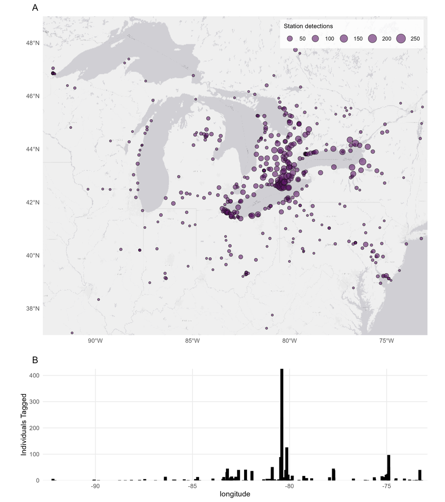

### Number of detections and tagging locations by longitude - Fall

Fall = Fall migration (August 15 - November 15)

Tagging effort also lines up with detections in fall

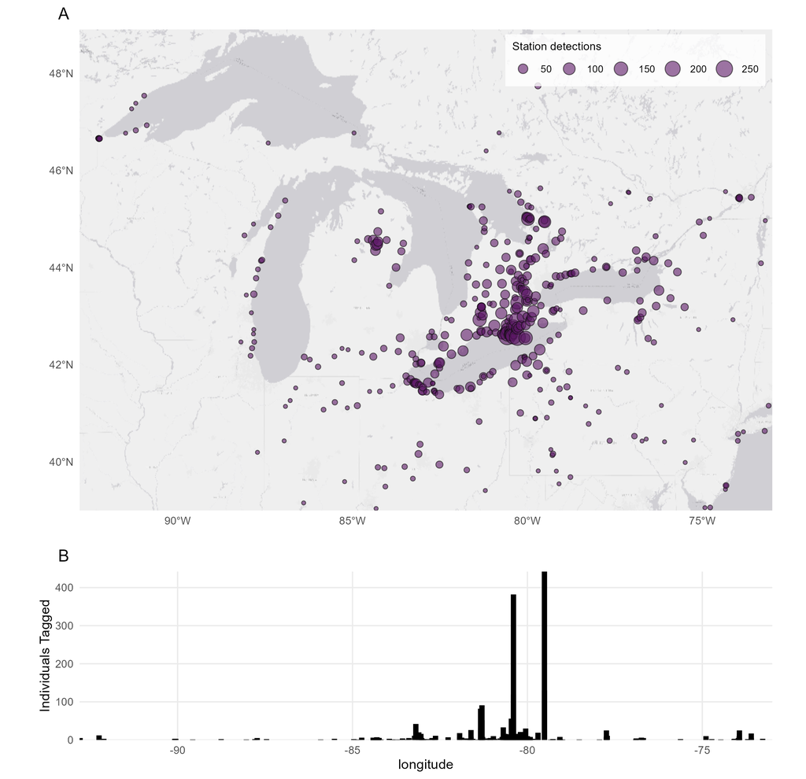

## Migration timing categories vs. flight times recorded

Species were categorized into migration time groups based on Winger et al 2019, Ralph 1981, Dufour et al 2026, Cornell BOW

Flights are colour coded by the timing of the flight: daytime, or night flight

Day flights = any flight that started and ended between sunrise and sunset Night flights = everything else.

NEXT STEPS: changing to show detection history by time rather than coarse categories of flight times.

### diurnal spring species (total detection = 267, 12 species)

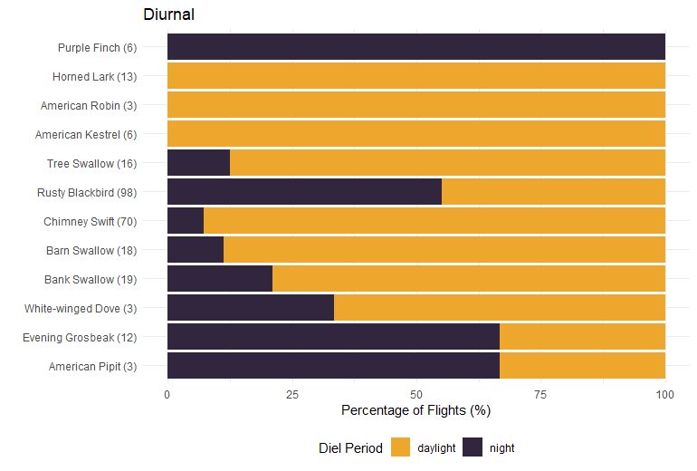

### mixed spring species (total detection = 1184, 10 species)

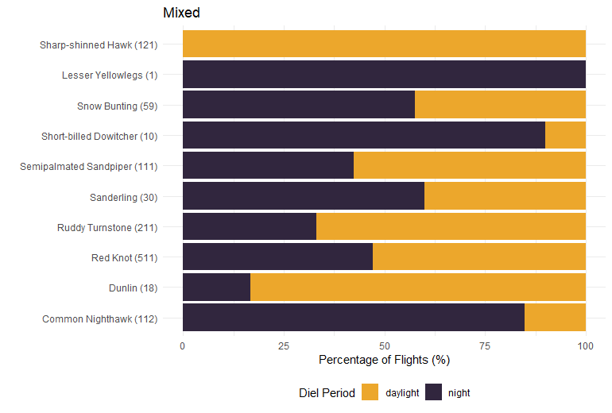

### nocturnal spring species (total detections = 2737, 39 species)

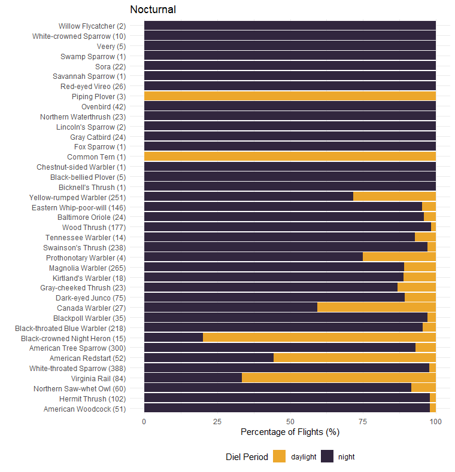

### diurnal fall species (total detections = 738, 14 species)

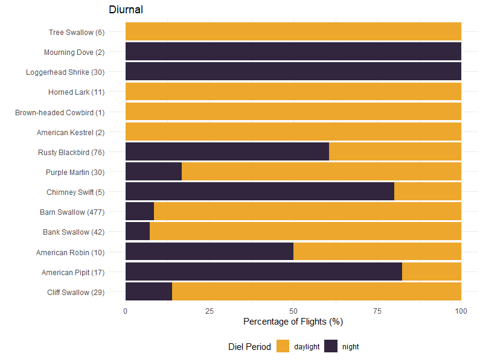

### mixed fall species (total detections = 476, 11 species)

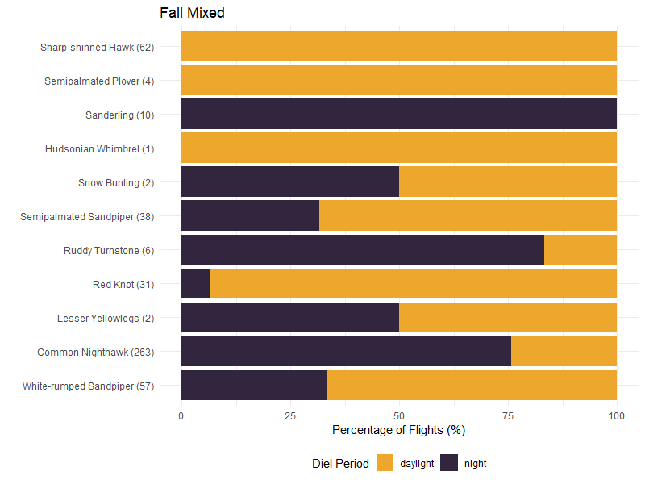

### nocturnal fall species (total detection = 2490, 43 species)

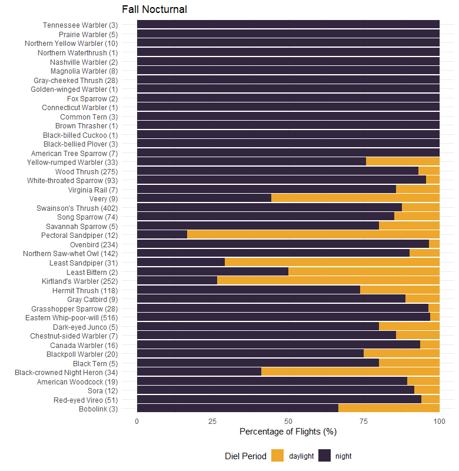

#### Migration timing of each species

used Winger et al 2019, Ralph 1981, Dufour et al 2026, Cornell BOW

|  | Species | Migration Timing |
| --- | --- | --- |
| 1 | American Kestrel | diurnal |
| 2 | American Oystercatcher | diurnal |
| 3 | American Pipit | diurnal |
| 4 | American Robin | diurnal |
| 5 | Bank Swallow | diurnal |
| 6 | Barn Swallow | diurnal |
| 7 | Blue Jay | diurnal |
| 8 | Brown-headed Cowbird | diurnal |
| 9 | Chestnut-collared Longspur | diurnal |
| 10 | Chimney Swift | diurnal |

[output cut: 126 more lines]

## Histogram of Departure/Landing times

These are spring flights of just birds at night. Only the first detection of a flight for an individual was included (i.e., if the flight had multiple steps, only the first step was included)

We did this to try and determine time cut offs for take off and landing for nocturnal birds.

The histograms show number of first/last steps in the flight by hour from sunset/sunrise for departure and take off respectively

### Departure flights for spring

Based on these histograms:

Take-off = 0.5 hour before sunset and 2 hours after sunset) Landing = 4 hours before sunrise and 0.5 hours after sunrise

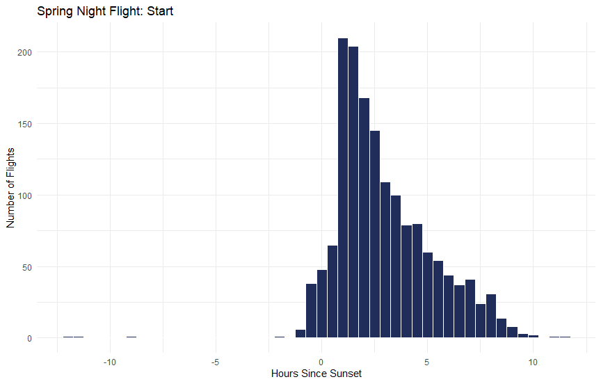

### Landing flights for spring

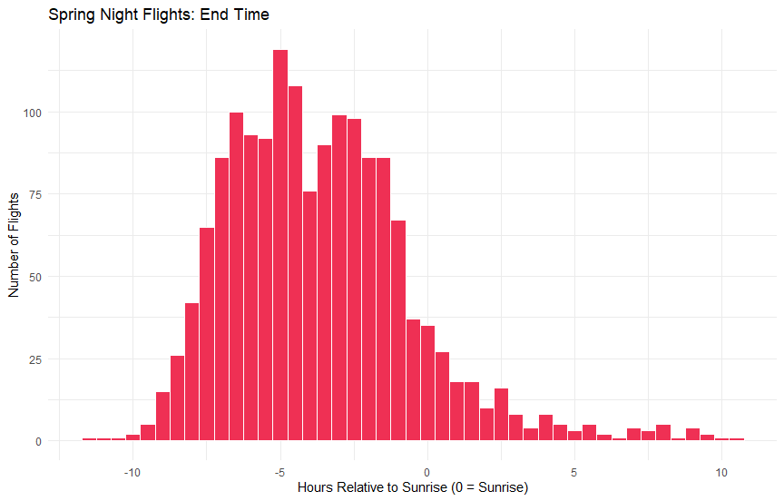

### departure flights for Fall

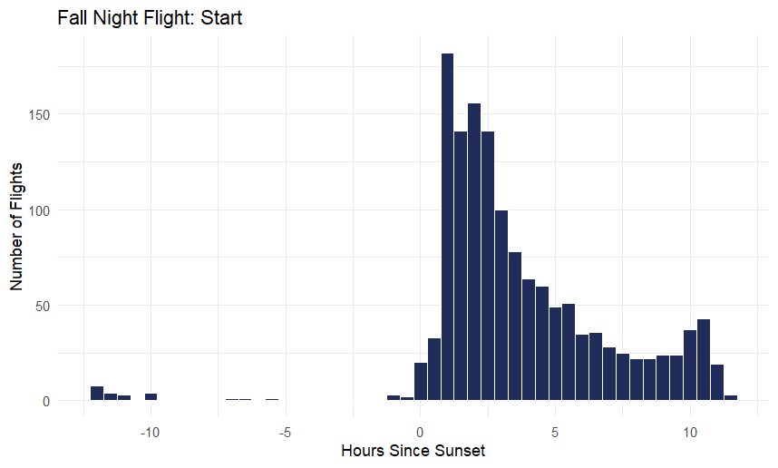

### landing flights fall

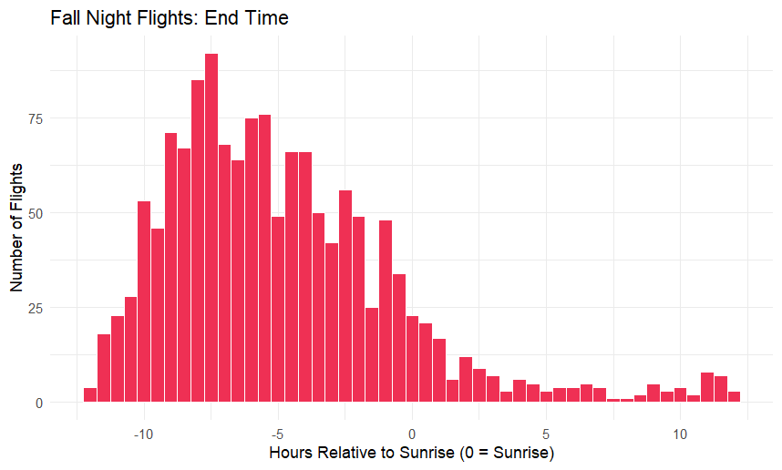

## Key Migration Areas

### prioritizr

prioritzr is an R package for systematic conservation prioritization. designed to “solve” different conservation problems using optimization algorithms - e.g., help decide which land parcels to purchase to get the most “bang for your buck”

https://prioritizr.net/

For prioritizr you need:

1. biodiversity data
2. choose an objective (specific function) and targets/budget dependong on the objective
3. cost

For this project: 1. is the flight data represented as a stacked Multispecies Line Kernel Density Estimation

#### example of Multispecies LKDE for all birds

[figure not shown]

2. The objective is a specific function in prioritizr. The one I selected aims to maximize biodiversity while minimizing cost. To maximize biodiversity you select a target that you get the algorithm to hit in the solution. Because the data is flight density, the target would be X amount of flight density of each species must be in the solution.
3. For this project the “cost” data is area so it tries to pick the solution with the least amount of area while meeting the objective

I ran 9 different scenarios across these combinations - threshold the KDE rasters to the top: 75%, 50% and 30% - targets (how much of each species KDE to keep): 17%, 30%, 50%

This output shows the pixels that were most often selected across the 9 scenarios for All Birds

#### This is the output for all birds

[interactive chart not shown]

### This is the selection frequency map for all nocturnal spring birds

[interactive chart not shown]

### Fall all nocturnal birds selection frequency map

[interactive chart not shown]

### This is the selection frequency for spring nocturnal takeoff

[interactive chart not shown]

### selection frequency for fall nocturnal takeoff

[interactive chart not shown]

### This is the selection frequency for spring nocturnal landing

[interactive chart not shown]

### Selection frequency for fall nocturnal landing

[interactive chart not shown]

### The selection frequency for spring diurnal birds

[interactive chart not shown]

### Selection frequency for fall diurnal migrants

[interactive chart not shown]

### The selection frequency for all spring bats

[interactive chart not shown]

### The selection frequency for fall bats

[interactive chart not shown]

## Comparing Prioritizr output between seasons

## within group comparisons

### nocturnal birds

[interactive chart not shown]

### nocturnal birds takeoff

[interactive chart not shown]

### nocturnal birds landing

[interactive chart not shown]

### diurnal birds

[interactive chart not shown]

### bats

[interactive chart not shown]

## within season comparisons

NEXT STEPS: remove take off and landing layers, rename guilds to layers or something else

### spring

[interactive chart not shown]

### fall

[interactive chart not shown]

### both seasons

[interactive chart not shown]

NEXT STEPS

compare landcover between take off and landing

This output (Irreplaceability Rank Importance) shows which pixels are the most important to keep for a given scenario (so this would have to be done per scenario or select among them). I picked this scenario because it is the biggest in terms of pixels so I assumed it coverd most cases. In this scenario the threshold is the top 75% of the data and target of 50%

[interactive chart not shown]

This is rank importance of all Nocturnal Birds

[interactive chart not shown]

### Data preparation summary

The summary data was downloaded from all Motus Project #1 towers. The data are downloaded as “pairs” with the current and previous station noted

**Additional columns were added:**

- column for season
  - spring = March 1 - June 15
  - summer = June 15 - August 18
  - fall = August 15 - November 15
  - Winter = November 15- April 15
- column for sunrise/sunset time
- column for sunrise/sunset local time
- column for movement duration in hours
- a column for whether the detection is likely a flight (< 12 hrs duration) or an incident (> 12 hr duration)

**cleaning detections that went back in time**

There are detections where the end time is before the start time. These are some sort of error and need to be removed

## Flight information added

Flight specific information was added as additional columns This includes:

- flight number (sequential flights per individual)
- speed per step in the flight
- turning angle (where it could be calculated)
- diel period (daylight or night) of the flight
- hours from sunrise and sunset (can be used to identify flights close to take-off or landing)
- additional grouping variable added:
  - which subbasin the occurrence took place in within the GLWS

## Individual information added

Information about each individual was added including:

- the tag deployment coordinates
- sex/age of the individual (if the project included this)
- days post migration the detection occurred
- tagging location potential issue flags
  - whether the tagging location was inside or outside the GLWS
  - how far from the boundary and the closest lake shoreline the tagging location was

## Spring phenology

**Number of detections during spring**

```
## [1] 7928
```

**Number of species**

```
## [1] 96
```

**Number of tags**

```
## [1] 2812
```

### Spring Arrival Phenology by Subbasin Plots

```
## [1] 7928
```

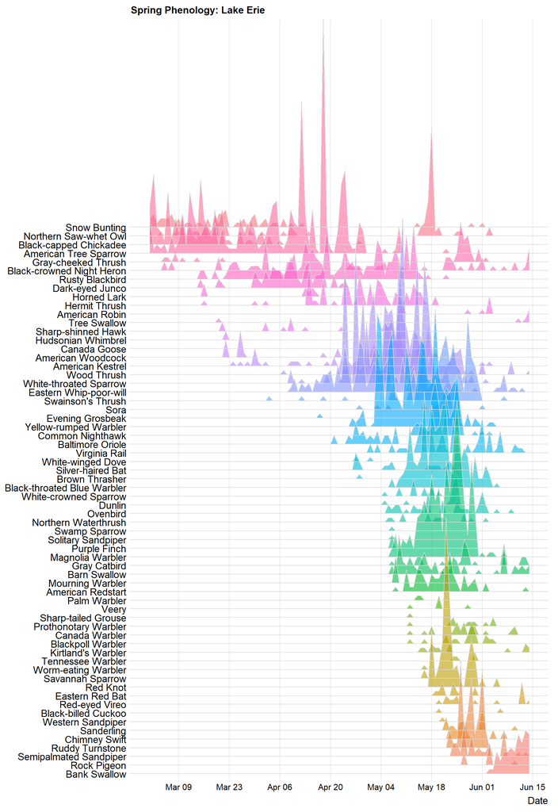

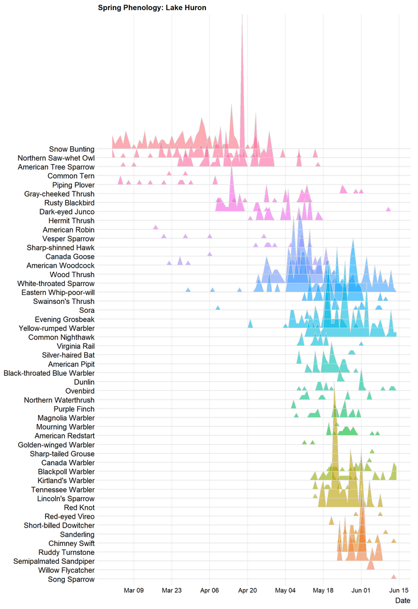

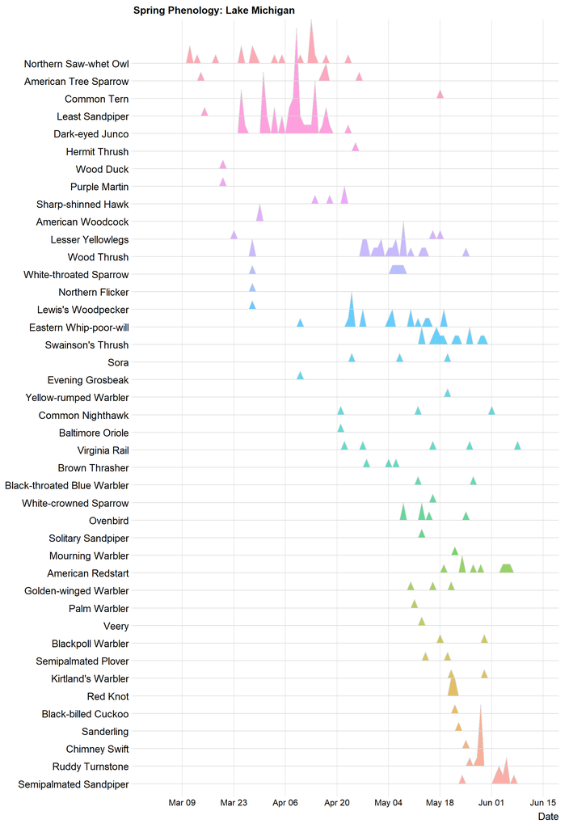

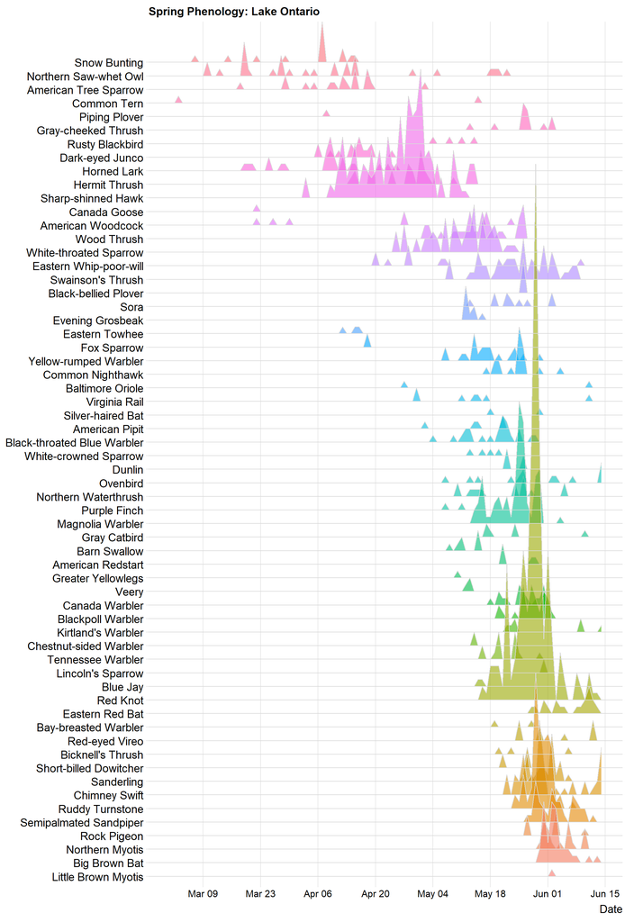

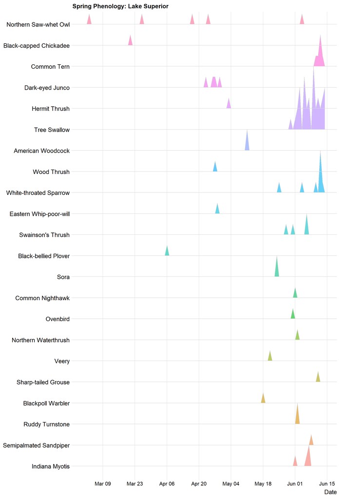